# SixTrackLib

### ... and GPU simulations of particle beams in synchrotrons

##### a notebook talk by Adrian Oeftiger (GSI) and Martin Schwinzerl (CERN, Uni Graz)

AMD and GSI meeting on 2 November 2020. See also [rendered talk on github $\nearrow$](https://aoeftiger.github.io/AMD-GSI-SixTrackLib-11-2020/) besides [source in github repo $\nearrow$](https://github.com/aoeftiger/AMD-GSI-SixTrackLib-11-2020/).

(hit space to go to the next slide)

# ... the origins ...

Legacy simulation code [`SixTrack` $\nearrow$](http://sixtrack.web.cern.ch/SixTrack/):

- used in volunteered computing network BOINC: [40TFLOPS, >170'000 registered users $\nearrow$](https://lhcathome.cern.ch/lhcathome/server_status.php)
- 72'000 lines of `Fortran77/90` code
- **identical** numerical results across OS and hardware platforms
- re-implemented from scratch as C-templated code [`SixTrackLib` $\nearrow$](https://github.com/sixtrack/sixtracklib)
- adding GPU support via `openCL` (and `CUDA`)

$\implies$ aim for both 1) distributed BOINC computing and 2) HPC on GPU clusters

[figure not shown]

# ... the applications of `SixTrackLib` ...

## GSI: SIS100 Magnet Field Errors

- SIS100 heavy-ion synchrotron under construction at GSI
- new magnets (dipoles, quadrupoles) built, measurements of field quality

$\implies$ `SixTrackLib` helps to evaluate impact of field errors on beam dynamics (long-term beam storage for 160'000 revolutions):

$\implies$ now 2 mins instead of 16 h / simulation

[figure not shown]

# ... the modelled physics ...

# Beam Model

3D particle motion $\leadsto$ 6 phase space coordinates: $$\mathbb{X}=(\underbrace{x, x'\vphantom{y'}}_{horizontal}, \underbrace{y, y'}_{vertical}, \underbrace{z, \delta\vphantom{y'}}_{longitudinal})$$

A beam $=$ state of $N$ macro-particles $=$ $6N$ values of phase space coordinates

[figure not shown]

# Accelerator Model

Symplectic non-linear 6D tracking through elements along accelerator ring:

[figure not shown]

# ... the numerics ...

## Simulations Requirements:

- **accurate**: long-term evolution $\leadsto$ double precision
- **fast**: heavy number crunching $\leadsto$ high-performance computing (HPC)  
  (in particular GPU parallelisation)
- **flexible**: iterative development of accelerator models with frequent updates $\leadsto$ python (API)

## Pseudo Code

```
for p in particles: // parallel!
    for n in range(nturns):
        for el_type, el_params in elements:
            p = track[el_type](el_params, p)
```

$\implies$ **embarrassingly parallel** simulations: particles treated separately

$\leadsto$ current implementation: single kernel with case-switch in `openCL`

| What |  | Typical numbers |
| --- | --- | --- |
| simulation length |  | $\mathcal{O}(10^4)$ to $\mathcal{O}(10^7)$ `nturns` |
| accelerator `elements` |  | $\mathcal{O}(10^3)$ to $\mathcal{O}(10^5)$ |
| element types ($10$ to $20$) |  | $20$ to $\mathcal{O}(10^5)$ arithmetic operations |
| element parameters |  | $1$ to $50$ `el_params` |
| macro-`particles` |  | $\mathcal{O}(10^4)$ to $\mathcal{O}(10^6)$ |

# ... what we are working on! ...

## Current Benchmarks

[figure not shown]

| AMD Radeon Instinct MI50 | AMD Radeon VII | NVIDIA RTX 2080 | NVIDIA V100 | CPU: AMD EPYC 7551 |
| --- | --- | --- | --- | --- |
| 6.7 TFLOPS | 3.5 TFLOPS | 0.44 TFLOPS | 7 TFLOPS | 0.65 TFLOPS |

## LHC Benchmark

[figure not shown]

## Hardware aim for SixTrackLib

- AMD Radeon Instinct cards in GSI HPC cluster
- lots of LHC@home users with AMD gaming GPUs

## Issues to collaborate on with AMD

1. detailed **profiling** on AMD GPU hardware
2. **register spilling** throttles throughput: parallelisation approach to be optimised?

## For topic 1: Profiling

Various setups:

| Environment | Card | Driver |
| --- | --- | --- |
| GSI cluster | Radeon Instinct MI50 | ROCM |
| GSI workstation | Radeon VII | amdgpu-pro |
| CERN workstation | Radeon VII | ROCM |

$\implies$ can provide a typical simulation setup to profile / benchmark

(see also appendix for simple SIS100 example)

## For topic 2: Optimisation

$\implies$ Martin Schwinzerl implemented simple demo of SixTrackLib to play with:

https://github.com/martinschwinzerl/demotrack

- self-contained library in `openCL` (interfaced to `python` via `pyopencl`)
- particles, beam elements, track kernel
- light-weight elements (`Drift`, `Multipole`, `Cavity`) and suspected register spilling element (`SpaceChargeCoasting` using `cerrf`)

# Looking very forward to collaborate with you!

# Thank you for your attention

# // Appendix: SixTrackLib Example //

```python
import numpy as np
import sixtracklib

import time
```

```python
elements = sixtracklib.Elements.fromfile('sis100.bin')

nturns = 128
elements.BeamMonitor(num_stores=nturns);
```

```python
npart = 50 * 1024
particles = sixtracklib.Particles.from_ref(npart, p0c=1e9)
```

```python
particles.x += np.linspace(0, 1e-3, npart)
particles.y += -np.linspace(0, 1e-3, npart)
```

The trackjob will define the simulation kernel for us:

```python
job = sixtracklib.TrackJob(elements, particles, device="opencl:2.0")
```

```python
!clinfo -l
```

```
Platform #0: Portable Computing Language
 `-- Device #0: pthread-AMD Ryzen Threadripper 1950X 16-Core Processor
Platform #1: NVIDIA CUDA
 `-- Device #0: GeForce RTX 2080 Ti
Platform #2: AMD Accelerated Parallel Processing
 `-- Device #0: gfx906
```

## Let's track

```python
t0 = time.time()

job.track_until(nturns)
job.collect()

dt = time.time() - t0
print (dt) #20.15 sec without BeamMonitor
```

```
20.447933435440063
```

# Evaluation:

```python
rec_x = job.output.particles[0].x
rec_y = job.output.particles[0].y
```

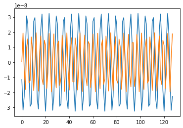

```python
import matplotlib.pyplot as plt
%matplotlib inline

plt.plot(rec_x[1::npart])
plt.plot(rec_y[1::npart])
```